# Homework 02

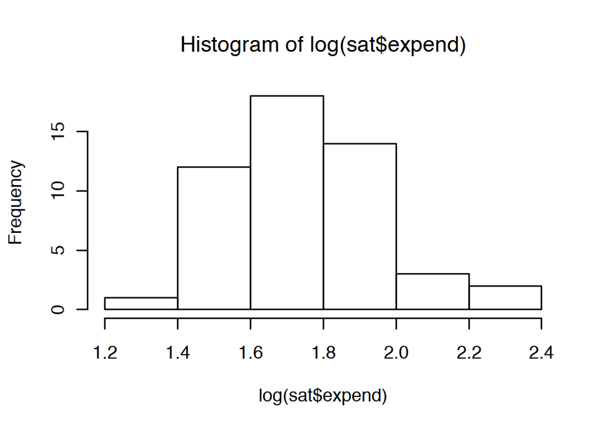

```r
hist(log(sat$expend))
```

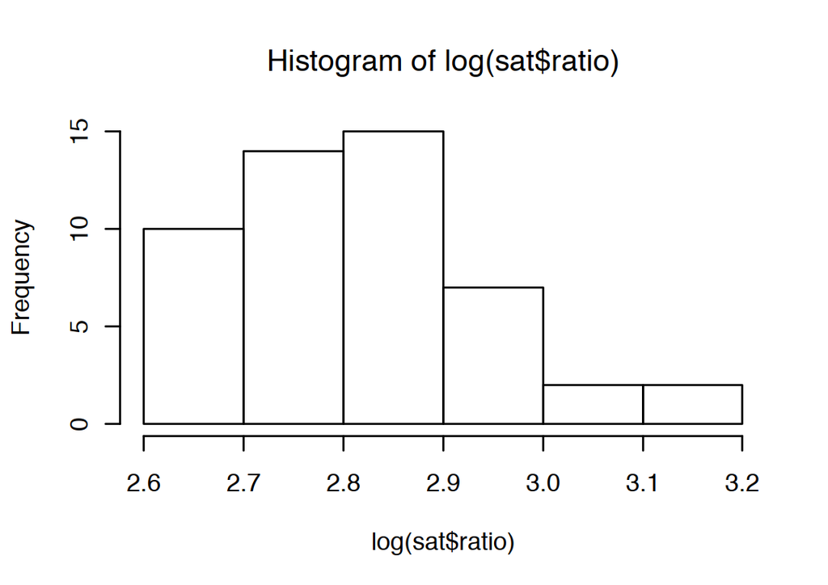

```r
hist(log(sat$ratio))
```

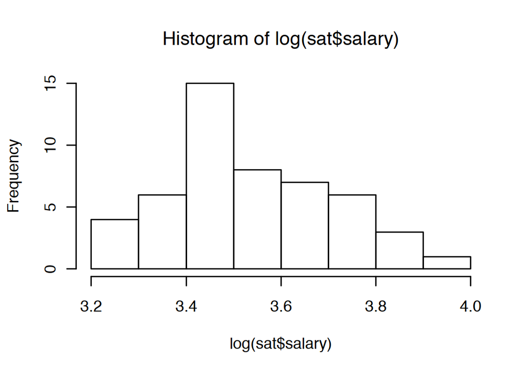

```r
hist(log(sat$salary))
```

```r
sat1 = mutate(sat,log.expend = log(expend))%>%mutate(log.ratio = log(ratio))%>%mutate(log.salary = log(salary))%>%mutate(meanlog.expend = log.expend-mean(log.expend))%>%mutate(meanlog.ratio = log.ratio-mean(log.ratio))%>%mutate(meanlog.salary = log.salary-mean(log.salary))%>%mutate(meantakers = takers-mean(takers))
satMD1 = lm(data = sat1, total ~ meanlog.expend + meanlog.ratio + meanlog.salary)
summary(satMD1)
```

```
##
## Call:
## lm(formula = total ~ meanlog.expend + meanlog.ratio + meanlog.salary,
##     data = sat1)
##
## Residuals:
##      Min       1Q   Median       3Q      Max
## -141.883  -45.280   -8.312   47.040  125.150
##
## Coefficients:
##                Estimate Std. Error t value Pr(>|t|)
## (Intercept)     965.920      9.627 100.332   <2e-16 ***
## meanlog.expend   92.895    133.651   0.695   0.4905
## meanlog.ratio   117.352    121.224   0.968   0.3381
## meanlog.salary -311.093    161.183  -1.930   0.0598 .
## ---
## Signif. codes:  0 '***' 0.001 '**' 0.01 '*' 0.05 '.' 0.1 ' ' 1
##
## Residual standard error: 68.08 on 46 degrees of freedom
## Multiple R-squared:  0.2229, Adjusted R-squared:  0.1722
## F-statistic: 4.397 on 3 and 46 DF,  p-value: 0.008403
```

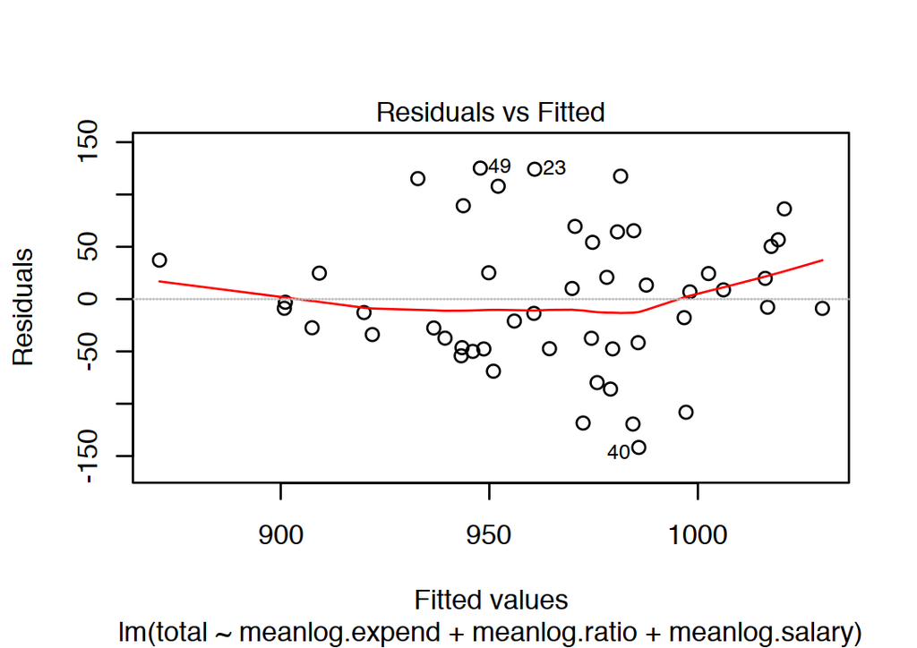

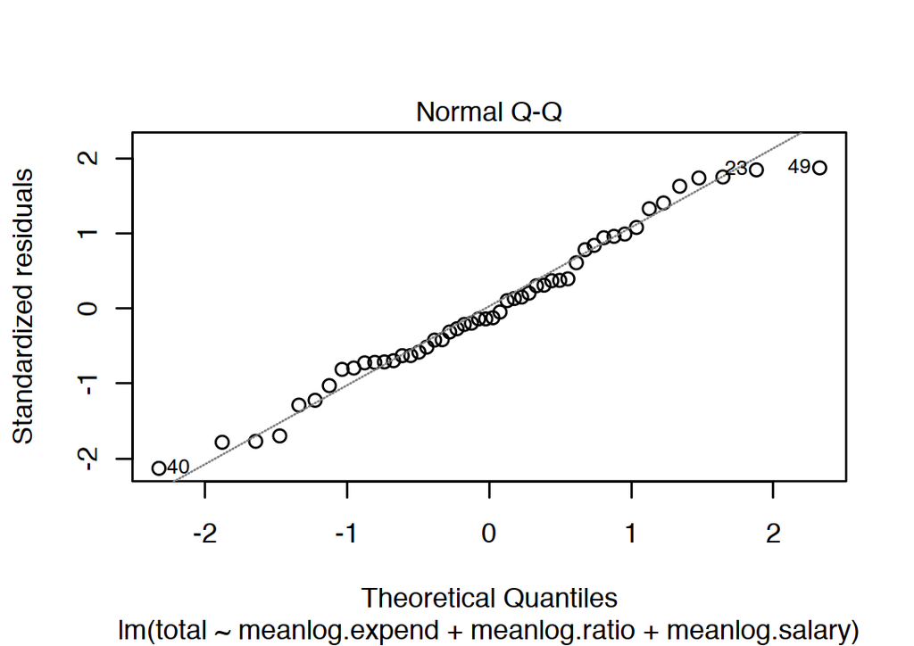

```r
plot(satMD1,which = 1:2)
```

intercept means average SAT score for average log.expend, average log.ratio and average log.salary The coef of meanlog.expend for every unit increase in log expend, SAT scores would expect to increase 92.895. The coef of meanlog.ratio means for every unit increase in log ratio, SAT scores would expect to increase 117.352 the coef of meanlog.salary means for every unit increse in log salary, SAT scores would expect to decrese 311.093

```r
satsum = as_tibble(summary(satMD1)$coef)%>%select(1:2)%>%`colnames<-`(c('Est','StandardError'))%>%mutate(lower95CI = Est-2*StandardError)%>%mutate(upper95CI = Est+2*StandardError)%>%`rownames<-`(rownames(summary(satMD1)$coef))
kable(satsum,format = 'html',digits = 2,align = 'c')
```

|  | Est | StandardError | lower95CI | upper95CI |
| --- | --- | --- | --- | --- |
| (Intercept) | 965.92 | 9.63 | 946.67 | 985.17 |
| meanlog.expend | 92.90 | 133.65 | -174.41 | 360.20 |
| meanlog.ratio | 117.35 | 121.22 | -125.10 | 359.80 |
| meanlog.salary | -311.09 | 161.18 | -633.46 | 11.27 |

the takeaway is that, there might not be an actual correlation between SAT scores and the predictors 3. Now add takers to the model. Compare the fitted model to the previous model and discuss which of the model seem to explain the outcome better?

```r
satMD2 = lm(data = sat1, total ~ meanlog.expend + meanlog.ratio + meanlog.salary + meantakers)
anova(satMD1,satMD2)
```

|  | Res.Df | RSS | Df | Sum of Sq | F | Pr(>F) |
| --- | --- | --- | --- | --- | --- | --- |
| 1 | 46 | 213173.67 | NA | NA | NA | NA |
| 2 | 45 | 48029.54 | 1 | 165144.1 | 154.7274 | 3.657151e-16 |

```r
summary(satMD1)
```

```
##
## Call:
## lm(formula = total ~ meanlog.expend + meanlog.ratio + meanlog.salary,
##     data = sat1)
##
## Residuals:
##      Min       1Q   Median       3Q      Max
## -141.883  -45.280   -8.312   47.040  125.150
##
## Coefficients:
##                Estimate Std. Error t value Pr(>|t|)
## (Intercept)     965.920      9.627 100.332   <2e-16 ***
## meanlog.expend   92.895    133.651   0.695   0.4905
## meanlog.ratio   117.352    121.224   0.968   0.3381
## meanlog.salary -311.093    161.183  -1.930   0.0598 .
## ---
## Signif. codes:  0 '***' 0.001 '**' 0.01 '*' 0.05 '.' 0.1 ' ' 1
##
## Residual standard error: 68.08 on 46 degrees of freedom
## Multiple R-squared:  0.2229, Adjusted R-squared:  0.1722
## F-statistic: 4.397 on 3 and 46 DF,  p-value: 0.008403
```

```r
summary(satMD2)
```

```
##
## Call:
## lm(formula = total ~ meanlog.expend + meanlog.ratio + meanlog.salary +
##     meantakers, data = sat1)
##
## Residuals:
##     Min      1Q  Median      3Q     Max
## -92.613 -20.727   0.343  13.809  67.984
##
## Coefficients:
##                Estimate Std. Error t value Pr(>|t|)
## (Intercept)    965.9200     4.6202 209.063  < 2e-16 ***
## meanlog.expend  15.9424    64.4382   0.247    0.806
## meanlog.ratio  -79.9294    60.2999  -1.326    0.192
## meanlog.salary  71.8433    83.2543   0.863    0.393
## meantakers      -2.9199     0.2347 -12.439 3.66e-16 ***
## ---
## Signif. codes:  0 '***' 0.001 '**' 0.01 '*' 0.05 '.' 0.1 ' ' 1
##
## Residual standard error: 32.67 on 45 degrees of freedom
## Multiple R-squared:  0.8249, Adjusted R-squared:  0.8093
## F-statistic:    53 on 4 and 45 DF,  p-value: < 2.2e-16
```

clearly from the anova test, adding takers significantly improve the fit # Conceptual exercises.

### Special-purpose transformations:

For a study of congressional elections, you would like a measure of the relative amount of money raised by each of the two major-party candidates in each district. Suppose that you know the amount of money raised by each candidate; label these dollar values $D_i$ and $R_i$. You would like to combine these into a single variable that can be included as an input variable into a model predicting vote share for the Democrats.

Discuss the advantages and disadvantages of the following measures:

- The simple difference, $D_i-R_i$
  - advantages includes
    - substraction provides quick classification from plus and minus sign.
    - know the exact difference
  - disadvantages includes
    - zero and negative value can be a problem for future transformation.
    - lose the knowledge of how close or how different the two party is(eg: 5500$ difference with each raised over 1mil vs. 500$ difference with each raised 5000ish)
- The ratio, $D_i/R_i$
  - advantages includes
    - quick classification comparing to ‘1’
    - always greater than zero, easy to transform
  - disadvantages includes
    - lose the exact amount of difference in raised money
    - when $R_i$ isa small, increases rapidly, not evenly distributed.
- The difference on the logarithmic scale, $log D_i-log R_i$
  - is esentailly taking log on $D_i/R_i$
  - resolve some distribution issue, but still lose the exact amount difference info.
- The relative proportion, $D_i/(D_i+R_i)$.
  - well organized, scale from 0 to 1.
  - but lose info on actual amount

### Transformation

For observed pair of $\mathrm{x}$ and $\mathrm{y}$, we fit a simple regression model
$$\mathrm{y}=\alpha + \beta \mathrm{x} + \mathrm{\epsilon}$$
which results in estimates $\hat{\alpha}=1$, $\hat{\beta}=0.9$, $SE(\hat{\beta})=0.03$, $\hat{\sigma}=2$ and $r=0.3$.

1. Suppose that the explanatory variable values in a regression are transformed according to the $\mathrm{x}^{\star}=\mathrm{x}-10$ and that $\mathrm{y}$ is regressed on $\mathrm{x}^{\star}$. Without redoing the regression calculation in detail, find $\hat{\alpha}^{\star}$, $\hat{\beta}^{\star}$, $\hat{\sigma}^{\star}$, and $r^{\star}$. What happens to these quantities when $\mathrm{x}^{\star}=10\mathrm{x}$ ? When $\mathrm{x}^{\star}=10(\mathrm{x}-1)$? When $\mathrm{x}^{\star}=\mathrm{x}-10$
   $$\alpha^{\star} = \alpha - 10 \cdot \beta$$
   $$\beta^{\star} = \beta$$
   $$\sigma^{\star} = \sigma$$
   When $\mathrm{x}^{\star}=10\mathrm{x}$
   $$\alpha^{\star} = \alpha$$
   $$\beta^{\star} = \beta/10$$
   $$\sigma^{\star} = \sigma$$
   When $\mathrm{x}^{\star}=10(\mathrm{x}-1)$
   $$\alpha^{\star} = \alpha-\beta$$
   $$\beta^{\star} = \beta/10$$
   $$\sigma^{\star} = \sigma$$
2. Now suppose that the response variable scores are transformed according to the formula $\mathrm{y}^{\star\star}= \mathrm{y}+10$ and that $\mathrm{y}^{\star\star}$ is regressed on $\mathrm{x}$. Without redoing the regression calculation in detail, find $\hat{\alpha}^{\star\star}$, $\hat{\beta}^{\star\star}$, $\hat{\sigma}^{\star\star}$, and $r^{\star\star}$. What happens to these quantities when $\mathrm{y}^{\star\star}=5\mathrm{y}$ ? When $\mathrm{y}^{\star\star}=5(\mathrm{y}+2)$? When $\mathrm{y}^{\star\star}=a(\mathrm{y}+b) , a\neq0$
   $$\alpha^{\star\star} = a(\alpha+b)$$
   $$\beta^{\star\star} = a\cdot\beta$$
   $$\sigma^{\star\star} = \sqrt{a}\cdot\sigma$$
3. In general, how are the results of a simple regression analysis affected by linear transformations of $\mathrm{y}$ and $\mathrm{x}$? rules: multiplication on $x$ equals to divide the $\beta$ term, substraction of $x$ equals to add substraction $\times \beta$ to the intercept multiplication on $y$ equals to multiplication on all coeficients, substraction on $y$ equals to substract on intercept
4. Suppose that the explanatory variable values in a regression are transformed according to the $\mathrm{x}^{\star}=10(\mathrm{x}-1)$ and that $\mathrm{y}$ is regressed on $\mathrm{x}^{\star}$. Without redoing the regression calculation in detail, find $SE(\hat{\beta}^{\star})$ and $t^{\star}_0= \hat{\beta}^{\star}/SE(\hat{\beta}^{\star})$.
5. Now suppose that the response variable scores are transformed according to the formula $\mathrm{y}^{\star\star}=5(\mathrm{y}+2)$ and that $\mathrm{y}^{\star\star}$ is regressed on $\mathrm{x}$. Without redoing the regression calculation in detail, find $SE(\hat{\beta}^{\star\star})$ and $t^{\star\star}_0= \hat{\beta}^{\star\star}/SE(\hat{\beta}^{\star\star})$.
6. In general, how are the hypothesis tests and confidence intervals for $\beta$ affected by linear transformations of $\mathrm{y}$ and $\mathrm{x}$?

# Feedback comments etc.

If you have any comments about the homework, or the class, please write your feedback here. We love to hear your opinions.

modeling took too much time to finish, and they are not really different from one another, conceptual questions are much more fun